# Project: Movie Database analysis

## Table of Content

- Introduction
- Data Wrangling
- Exploratory Data Analysis
- Conclusions

## Introduction

The reviewed dataset contains information about over 10,000 movies gathered from The Movie Databased (TMDb) including users ratings and revenue.

Some people see movie industry as being very creative, it still remains a high-cost business where the cost of failure can be fatal.

In this analysis we will try to understand how much would it cost to produce a movie, how much profit different genres are generating in average and what genre might be more fail-proof.

### Questions to be covered during analysis

1. What genres usually generate more revenue? Does the genre that ends up high-revenue one remains the most profitable?
2. How much it cost to produce a movie in average - per genre?
3. How the median production cost been changing over time? Per genre?
4. How the average movie profit changed over time for movies with high, medium and low production costs?

```python
# let's import all libraries that will be used during the analysis

import pandas as pd
import numpy as np
import matplotlib.pyplot as plt
import seaborn as sns
import os
from datetime import datetime, date
```

### All variables description

**id** - movie id

**imbd_id** - Movie ID on IMDB website

**popularity** - TMBD popularity criteria based on its own algorithm

**budget** - Movie production budget, US Dollars

**revenue** - Movie revenue, US Dollars

**original_title** - Movie Title

**cast** - Key actors participated in movie production

**homepage** - Movie website

**director** - Movie director

**tagline** - Main copyright used to promote the movie

**keywords** - Key hashtags decribing the movie including location, genre, topic, etc.

**overview** - Brief movie description

**runtime** - Movie Duration, mins

**genres** - Movie genre

**production_companies** - Companies that produced the movie

**release_date** - Date the movie was released, month/date/year format (mm/dd/yy)

**vote_count** - The average number of users rated the movie

**vote_average** - The average vote score

**release_year** - The year movie was released

**budget_adj** - The budget of the associated movie in terms of 2010 dollars, accounting for inflation over time.

**revenue_adj** - The revenue of the associated movie in terms of 2010 dollars, accounting for inflation over time.

## Data Wrangling

### General properties

```python
#Reading the file first and looking into the structure
os.chdir('/Users/601526/Documents/Python/uda_ndgr/Assignment_1')
df = pd.read_csv('tmdb-movies.csv')
pd.set_option('display.max_rows', 500)
pd.set_option('display.max_columns', 500)
pd.set_option('display.width', 1000)
```

```python
df.dtypes
```

```
id                        int64
imdb_id                  object
popularity              float64
budget                    int64
revenue                   int64
original_title           object
cast                     object
homepage                 object
director                 object
tagline                  object
keywords                 object
overview                 object
runtime                   int64
genres                   object
production_companies     object
release_date             object
vote_count                int64
vote_average            float64
release_year              int64
budget_adj              float64
revenue_adj             float64
dtype: object
```

Based on questions we've imposed before the start of the analysis and existing dataset structure, we need to do a few things:

1. Leave columns that will be used during analysis:
   - id
   - original_title
   - director
   - runtime
   - genres
   - release_date
   - vote_count
   - vote_average
   - budget_adj
   - revenue_adj
   - release_year
1. Clean dataset from any present duplicates, NaN values and other.
1. Identify anomalies, trace the potential reason and either fill those or remove such observations:
   - zero production costs
   - too high or too low runtime
   - too low or too high revenue
1. Create column on profit calculated as a budget subtracted from the revenue
1. Breakdown genres columns for better clarity
1. Format and fix date and year formats

```python
df.describe()
```

|  | id | popularity | budget | revenue | runtime | vote_count | vote_average | release_year | budget_adj | revenue_adj |
| --- | --- | --- | --- | --- | --- | --- | --- | --- | --- | --- |
| count | 10866.000000 | 10866.000000 | 1.086600e+04 | 1.086600e+04 | 10866.000000 | 10866.000000 | 10866.000000 | 10866.000000 | 1.086600e+04 | 1.086600e+04 |
| mean | 66064.177434 | 0.646441 | 1.462570e+07 | 3.982332e+07 | 102.070863 | 217.389748 | 5.974922 | 2001.322658 | 1.755104e+07 | 5.136436e+07 |
| std | 92130.136561 | 1.000185 | 3.091321e+07 | 1.170035e+08 | 31.381405 | 575.619058 | 0.935142 | 12.812941 | 3.430616e+07 | 1.446325e+08 |
| min | 5.000000 | 0.000065 | 0.000000e+00 | 0.000000e+00 | 0.000000 | 10.000000 | 1.500000 | 1960.000000 | 0.000000e+00 | 0.000000e+00 |
| 25% | 10596.250000 | 0.207583 | 0.000000e+00 | 0.000000e+00 | 90.000000 | 17.000000 | 5.400000 | 1995.000000 | 0.000000e+00 | 0.000000e+00 |
| 50% | 20669.000000 | 0.383856 | 0.000000e+00 | 0.000000e+00 | 99.000000 | 38.000000 | 6.000000 | 2006.000000 | 0.000000e+00 | 0.000000e+00 |
| 75% | 75610.000000 | 0.713817 | 1.500000e+07 | 2.400000e+07 | 111.000000 | 145.750000 | 6.600000 | 2011.000000 | 2.085325e+07 | 3.369710e+07 |
| max | 417859.000000 | 32.985763 | 4.250000e+08 | 2.781506e+09 | 900.000000 | 9767.000000 | 9.200000 | 2015.000000 | 4.250000e+08 | 2.827124e+09 |

### Data Cleaning

```python
#dropping columns we don't need in the analysis
df1 = df[['id','original_title', 'director','budget','revenue', 'runtime', 'genres', 'release_date', 'vote_count', 'vote_average', 'budget_adj', 'revenue_adj','release_year']]

#checking if dataset contains duplicates

dup = df1[df1.duplicated()]
print(dup)
```

```
         id original_title          director    budget  revenue  runtime                                       genres release_date  vote_count  vote_average  budget_adj  revenue_adj  release_year
2090  42194         TEKKEN  Dwight H. Little  30000000   967000       92  Crime|Drama|Action|Thriller|Science Fiction      3/20/10         110           5.0  30000000.0     967000.0          2010
```

#### Dropping NAs

After removing unnecessary columns, only one duplicate is discovered, which can be safely removed. In addition, let's see how many rows are containining null values and see if something can be done about it.

```python
#dropping duplicated row
df1.drop_duplicates(keep = 'first', inplace = True)


#checking dataset for na's

df1.isnull().values.any()
```

```
True
```

```python
#selecting na to a separate dataset
df_na = df1[df1.isna().any(axis=1)]

#running the code to display all rows

pd.set_option('display.max_rows', df_na.shape[0]+1)

df_na
```

|  | id | original_title | director | budget | revenue | runtime | genres | release_date | vote_count | vote_average | budget_adj | revenue_adj | release_year |
| --- | --- | --- | --- | --- | --- | --- | --- | --- | --- | --- | --- | --- | --- |
| 424 | 363869 | Belli di papÃ | Guido Chiesa | 0 | 0 | 100 | NaN | 10/29/15 | 21 | 6.1 | 0.000000e+00 | 0.000000e+00 | 2015 |
| 532 | 320996 | Iliza Shlesinger: Freezing Hot | NaN | 0 | 0 | 71 | Comedy | 1/23/15 | 14 | 6.6 | 0.000000e+00 | 0.000000e+00 | 2015 |
| 548 | 355131 | Sense8: Creating the World | NaN | 0 | 0 | 25 | Documentary\|Science Fiction | 8/10/15 | 12 | 7.5 | 0.000000e+00 | 0.000000e+00 | 2015 |
| 556 | 321160 | With This Ring | NaN | 0 | 0 | 105 | Comedy\|Romance | 1/24/15 | 14 | 6.5 | 0.000000e+00 | 0.000000e+00 | 2015 |
| 620 | 361043 | All Hallows' Eve 2 | Antonio Padovan\|Bryan Norton\|Marc Roussel\|Ryan... | 0 | 0 | 90 | NaN | 10/6/15 | 13 | 5.0 | 0.000000e+00 | 0.000000e+00 | 2015 |
| 997 | 287663 | Star Wars Rebels: Spark of Rebellion | Steward Lee\|Steven G. Lee | 0 | 0 | 44 | NaN | 10/3/14 | 13 | 6.8 | 0.000000e+00 | 0.000000e+00 | 2014 |
| 1032 | 259910 | Marvel Studios: Assembling a Universe | NaN | 0 | 0 | 43 | TV Movie\|Documentary | 3/18/14 | 32 | 6.3 | 0.000000e+00 | 0.000000e+00 | 2014 |
| 1054 | 253675 | Unlocking Sherlock | NaN | 0 | 0 | 60 | TV Movie\|Documentary | 1/19/14 | 11 | 7.2 | 0.000000e+00 | 0.000000e+00 | 2014 |
| 1203 | 256561 | Free to Play | NaN | 150000 | 0 | 75 | Documentary | 3/19/14 | 40 | 7.0 | 1.381637e+05 | 0.000000e+00 | 2014 |
| 1241 | 296370 | Dance-Off | NaN | 0 | 0 | 0 | Romance\|Music\|Comedy | 1/1/14 | 18 | 5.7 | 0.000000e+00 | 0.000000e+00 | 2014 |
| 1288 | 301235 | Top Gear: The Perfect Road Trip 2 | NaN | 0 | 0 | 94 | Documentary | 11/17/14 | 12 | 6.8 | 0.000000e+00 | 0.000000e+00 | 2014 |
| 1712 | 21634 | Prayers for Bobby | Russell Mulcahy | 0 | 0 | 88 | NaN | 2/27/09 | 57 | 7.4 | 0.000000e+00 | 0.000000e+00 | 2009 |
| 1852 | 133365 | The Diary of Anne Frank | NaN | 0 | 0 | 100 | Drama | 1/9/09 | 19 | 7.5 | 0.000000e+00 | 0.000000e+00 | 2009 |
| 1872 | 26379 | Paa | NaN | 3250000 | 0 | 133 | Drama\|Family\|Foreign | 12/4/09 | 11 | 6.1 | 3.303301e+06 | 0.000000e+00 | 2009 |
| 1895 | 281979 | Doctor Who: The Waters of Mars | NaN | 0 | 0 | 62 | Science Fiction\|Adventure\|Family | 12/19/09 | 25 | 8.0 | 0.000000e+00 | 0.000000e+00 | 2009 |
| 1897 | 40534 | Jonas Brothers: The Concert Experience | Bruce Hendricks | 0 | 0 | 76 | NaN | 2/27/09 | 11 | 7.0 | 0.000000e+00 | 0.000000e+00 | 2009 |
| 2221 | 48832 | Scott Pilgrim vs. the Animation | NaN | 0 | 0 | 4 | TV Movie\|Animation\|Adventure | 8/10/10 | 19 | 7.7 | 0.000000e+00 | 0.000000e+00 | 2010 |
| 2286 | 47911 | Bo Burnham: Words, Words, Words | NaN | 0 | 0 | 63 | Comedy | 10/19/10 | 13 | 6.5 | 0.000000e+00 | 0.000000e+00 | 2010 |
| 2290 | 51823 | Across the Line: The Exodus of Charlie Wright | NaN | 0 | 0 | 94 | Drama\|Action\|Thriller\|Crime | 12/28/10 | 11 | 6.0 | 0.000000e+00 | 0.000000e+00 | 2010 |
| 2315 | 48373 | Listen to Your Heart | NaN | 0 | 0 | 0 | Drama\|Music\|Romance | 8/14/10 | 29 | 7.3 | 0.000000e+00 | 0.000000e+00 | 2010 |
| 2318 | 34134 | Barbie in A Mermaid Tale | NaN | 0 | 0 | 75 | Animation\|Family\|Fantasy | 1/26/10 | 35 | 6.3 | 0.000000e+00 | 0.000000e+00 | 2010 |
| 2370 | 127717 | Freshman Father | Michael Scott | 0 | 0 | 0 | NaN | 6/5/10 | 12 | 5.8 | 0.000000e+00 | 0.000000e+00 | 2010 |
| 2376 | 315620 | Doctor Who: A Christmas Carol | NaN | 0 | 0 | 62 | NaN | 12/25/10 | 11 | 7.7 | 0.000000e+00 | 0.000000e+00 | 2010 |
| 2397 | 241829 | The Making of The Walking Dead | NaN | 0 | 0 | 30 | Documentary | 7/31/10 | 42 | 8.4 | 0.000000e+00 | 0.000000e+00 | 2010 |
| 2401 | 45644 | Opeth: In Live Concert At The Royal Albert Hall | NaN | 0 | 0 | 163 | Music | 9/21/10 | 10 | 8.6 | 0.000000e+00 | 0.000000e+00 | 2010 |
| 2403 | 72013 | Yu-Gi-Oh! 3D: Bonds Beyond Time | NaN | 0 | 0 | 60 | Animation\|Fantasy | 1/23/10 | 10 | 6.0 | 0.000000e+00 | 0.000000e+00 | 2010 |
| 2853 | 57892 | Vizontele | YÄ±lmaz ErdoÄŸan | 0 | 0 | 110 | NaN | 2/2/01 | 12 | 7.2 | 0.000000e+00 | 0.000000e+00 | 2001 |
| 3171 | 17171 | The Assassination of Jesse James: Death Of An ... | NaN | 0 | 0 | 32 | Documentary | 1/1/08 | 20 | 6.8 | 0.000000e+00 | 0.000000e+00 | 2008 |
| 3224 | 20313 | John Mayer: Where the Light Is Live in Los Ang... | NaN | 0 | 0 | 164 | Music | 7/1/08 | 16 | 8.5 | 0.000000e+00 | 0.000000e+00 | 2008 |
| 3276 | 15467 | Kismat Konnection | NaN | 4180000 | 11000000 | 153 | Drama\|Comedy\|Romance\|Foreign | 7/18/08 | 11 | 5.8 | 4.233448e+06 | 1.114065e+07 | 2008 |
| 3279 | 54330 | ì•„ê¸°ì™€ ë‚˜ | Kim Jin-Yeong | 0 | 0 | 96 | NaN | 8/13/08 | 11 | 6.1 | 0.000000e+00 | 0.000000e+00 | 2008 |
| 3285 | 36131 | Tropic Thunder: Rain of Madness | NaN | 0 | 0 | 30 | Action\|Comedy | 8/26/08 | 12 | 6.9 | 0.000000e+00 | 0.000000e+00 | 2008 |
| 3357 | 32836 | Bill Burr: Why Do I Do This? | NaN | 0 | 0 | 55 | Comedy | 9/23/08 | 10 | 8.0 | 0.000000e+00 | 0.000000e+00 | 2008 |
| 3365 | 22258 | Foo Fighters: Live at Wembley Stadium | NaN | 0 | 0 | 120 | Music | 8/25/08 | 10 | 8.4 | 0.000000e+00 | 0.000000e+00 | 2008 |
| 3369 | 77974 | Wizards On Deck With Hannah Montana | NaN | 0 | 0 | 68 | Family | 2/11/08 | 14 | 6.1 | 0.000000e+00 | 0.000000e+00 | 2008 |
| 3910 | 79976 | Steve Jobs: One Last Thing | NaN | 0 | 0 | 60 | Documentary | 11/2/11 | 11 | 6.6 | 0.000000e+00 | 0.000000e+00 | 2011 |
| 4547 | 123024 | London 2012 Olympic Opening Ceremony: Isles of... | Danny Boyle | 0 | 0 | 220 | NaN | 7/27/12 | 12 | 8.3 | 0.000000e+00 | 0.000000e+00 | 2012 |
| 4679 | 91342 | Barbie in A Mermaid Tale 2 | NaN | 0 | 0 | 74 | Animation\|Family | 2/23/12 | 22 | 6.0 | 0.000000e+00 | 0.000000e+00 | 2012 |
| 4732 | 139463 | The Scapegoat | Charles Sturridge | 0 | 0 | 100 | NaN | 9/9/12 | 12 | 6.2 | 0.000000e+00 | 0.000000e+00 | 2012 |
| 4797 | 369145 | Doctor Who: The Snowmen | NaN | 0 | 0 | 60 | NaN | 12/25/12 | 10 | 7.8 | 0.000000e+00 | 0.000000e+00 | 2012 |
| 4872 | 269177 | Party Bercy | NaN | 0 | 0 | 120 | Comedy | 9/23/12 | 15 | 6.4 | 0.000000e+00 | 0.000000e+00 | 2012 |
| 4890 | 126909 | Cousin Ben Troop Screening | Wes Anderson | 0 | 0 | 2 | NaN | 1/1/12 | 14 | 7.0 | 0.000000e+00 | 0.000000e+00 | 2012 |
| 4939 | 168219 | The Men Who Built America | NaN | 0 | 0 | 360 | Documentary\|History | 10/16/12 | 11 | 5.3 | 0.000000e+00 | 0.000000e+00 | 2012 |
| 5413 | 20378 | The Brave Little Toaster to the Rescue | NaN | 0 | 0 | 74 | Animation\|Comedy\|Family | 11/1/97 | 11 | 7.0 | 0.000000e+00 | 0.000000e+00 | 1997 |
| 5830 | 282848 | Doctor Who: The Time of the Doctor | James Payne | 0 | 0 | 60 | NaN | 12/25/13 | 26 | 8.5 | 0.000000e+00 | 0.000000e+00 | 2013 |
| 5866 | 246569 | Jinxed | NaN | 5000000 | 0 | 75 | Family\|Fantasy\|Comedy | 11/29/13 | 19 | 7.0 | 4.680167e+06 | 0.000000e+00 | 2013 |
| 5915 | 284019 | Phineas and Ferb: Mission Marvel | NaN | 0 | 0 | 44 | Action\|Adventure\|Science Fiction | 8/16/13 | 13 | 5.9 | 0.000000e+00 | 0.000000e+00 | 2013 |
| 5934 | 200204 | Prada: Candy | Wes Anderson\|Roman Coppola | 0 | 0 | 3 | NaN | 3/25/13 | 27 | 6.9 | 0.000000e+00 | 0.000000e+00 | 2013 |
| 5972 | 238234 | Top Gear: The Perfect Road Trip | NaN | 0 | 0 | 84 | TV Movie\|Action\|Adventure\|Documentary | 11/17/13 | 35 | 7.6 | 0.000000e+00 | 0.000000e+00 | 2013 |
| 6033 | 238185 | Russell Brand: Messiah Complex | NaN | 0 | 0 | 99 | Comedy | 11/25/13 | 12 | 6.8 | 0.000000e+00 | 0.000000e+00 | 2013 |
| 6043 | 190940 | Bombay Talkies | Anurag Kashyap\|Dibakar Banerjee\|Zoya Akhtar\|Ka... | 0 | 0 | 127 | NaN | 5/3/13 | 12 | 5.9 | 0.000000e+00 | 0.000000e+00 | 2013 |
| 6181 | 18729 | North and South, Book I | NaN | 0 | 0 | 561 | Drama\|History\|Western | 11/3/85 | 17 | 6.0 | 0.000000e+00 | 0.000000e+00 | 1985 |
| 6530 | 168891 | Saw Rebirth | Jeff Shuter\|Daniel Viney | 0 | 0 | 6 | NaN | 10/24/05 | 24 | 5.9 | 0.000000e+00 | 0.000000e+00 | 2005 |
| 7579 | 58432 | La hora frÃa | NaN | 0 | 0 | 92 | Horror\|Thriller\|Science Fiction\|Mystery\|Foreign | 9/14/07 | 10 | 4.9 | 0.000000e+00 | 0.000000e+00 | 2007 |
| 7767 | 282758 | Doctor Who: The Runaway Bride | NaN | 0 | 0 | 60 | Science Fiction\|TV Movie | 7/6/07 | 18 | 7.6 | 0.000000e+00 | 0.000000e+00 | 2007 |
| 7814 | 25565 | Transformers: Beginnings | NaN | 0 | 0 | 22 | Animation\|Action\|Thriller\|Science Fiction | 10/16/07 | 34 | 5.8 | 0.000000e+00 | 0.000000e+00 | 2007 |
| 8234 | 56804 | Viaggi di nozze | Carlo Verdone | 0 | 0 | 103 | NaN | 12/15/95 | 44 | 6.7 | 0.000000e+00 | 0.000000e+00 | 1995 |
| 8614 | 65595 | T2 3-D: Battle Across Time | James Cameron | 0 | 0 | 12 | NaN | 1/1/96 | 14 | 6.7 | 0.000000e+00 | 0.000000e+00 | 1996 |
| 8878 | 92208 | Mom's Got a Date With a Vampire | Steve Boyum | 0 | 0 | 85 | NaN | 10/13/00 | 16 | 5.4 | 0.000000e+00 | 0.000000e+00 | 2000 |
| 9307 | 141859 | Goldeneye | Don Boyd | 0 | 0 | 105 | NaN | 8/26/89 | 10 | 5.3 | 0.000000e+00 | 0.000000e+00 | 1989 |
| 9593 | 46188 | Peter Pan | NaN | 0 | 0 | 52 | Action\|Adventure\|Animation\|Family\|Fantasy | 1/1/88 | 28 | 6.6 | 0.000000e+00 | 0.000000e+00 | 1988 |
| 9799 | 48847 | The Amputee | David Lynch | 0 | 0 | 5 | NaN | 1/1/74 | 11 | 5.0 | 0.000000e+00 | 0.000000e+00 | 1974 |
| 10386 | 225804 | The Making of 'The Nightmare Before Christmas' | NaN | 0 | 0 | 25 | Documentary | 10/3/93 | 15 | 7.5 | 0.000000e+00 | 0.000000e+00 | 1993 |
| 10426 | 34038 | Magical Mystery Tour | NaN | 0 | 0 | 55 | Music | 12/25/67 | 15 | 5.8 | 0.000000e+00 | 0.000000e+00 | 1967 |
| 10659 | 4255 | The Party at Kitty and Stud's | Morton Lewis | 5000 | 0 | 71 | NaN | 2/10/70 | 10 | 3.0 | 2.808184e+04 | 0.000000e+00 | 1970 |

Since the director or genre are the only two columns with NA values present, plus these movies don't have assigned budget and revenue, it is probably easier to get rid of those for the sake of speed.

```python
#removing duplicates
df1.dropna(inplace = True)

#evaluating dataframe again
df1.describe()
```

|  | id | budget | revenue | runtime | vote_count | vote_average | budget_adj | revenue_adj | release_year |
| --- | --- | --- | --- | --- | --- | --- | --- | --- | --- |
| count | 10800.000000 | 1.080000e+04 | 1.080000e+04 | 10800.000000 | 10800.000000 | 10800.000000 | 1.080000e+04 | 1.080000e+04 | 10800.000000 |
| mean | 65576.183426 | 1.471114e+07 | 4.006558e+07 | 102.189722 | 218.600741 | 5.970880 | 1.765437e+07 | 5.167714e+07 | 2001.289537 |
| std | 91756.079939 | 3.098677e+07 | 1.173193e+08 | 30.783873 | 577.165055 | 0.933006 | 3.438403e+07 | 1.450182e+08 | 12.819545 |
| min | 5.000000 | 0.000000e+00 | 0.000000e+00 | 0.000000 | 10.000000 | 1.500000 | 0.000000e+00 | 0.000000e+00 | 1960.000000 |
| 25% | 10570.500000 | 0.000000e+00 | 0.000000e+00 | 90.000000 | 17.000000 | 5.400000 | 0.000000e+00 | 0.000000e+00 | 1995.000000 |
| 50% | 20460.000000 | 0.000000e+00 | 0.000000e+00 | 99.000000 | 39.000000 | 6.000000 | 0.000000e+00 | 0.000000e+00 | 2006.000000 |
| 75% | 74725.250000 | 1.564374e+07 | 2.455409e+07 | 111.250000 | 147.000000 | 6.600000 | 2.103337e+07 | 3.408743e+07 | 2011.000000 |
| max | 417859.000000 | 4.250000e+08 | 2.781506e+09 | 900.000000 | 9767.000000 | 9.200000 | 4.250000e+08 | 2.827124e+09 | 2015.000000 |

#### Fixing zero runtime

Now it's time to investigate the dataset for any potential anomalies. According to dataset description above, runtime contains zeros what obviously can't be true for the movie.

Further, we need to look into zero values reported in budget_adj (also barely can't be true), and also check if zero revenue values make any sense.

```python
#looking into dataset where runtime is zero
df1.query('runtime == 0')

#replacing zero for runtime with median value
df1['runtime'] = df1.runtime.mask(df1.runtime == 0, df1['runtime'].median())

#checking the dataframe
df1.query('runtime == 0')
```

|  | id | original_title | director | budget | revenue | runtime | genres | release_date | vote_count | vote_average | budget_adj | revenue_adj | release_year |
| --- | --- | --- | --- | --- | --- | --- | --- | --- | --- | --- | --- | --- | --- |

#### Fixing zero values for budget

Zero budget is a big deal that affects over 50% of the dataset. Let's reduce the number by replacing zero budget with median value.

```python
#let's look into zero value for budget and revenue
movies_budget_over_zero = df1.query('budget > 0')
budget_median = movies_budget_over_zero['budget'].median()
movies_budget_over_zero

#doing the same for budget_adj
budget_adj_median  = movies_budget_over_zero['budget_adj'].median()


#replace zero budget with median value

df1['budget'] = df1.budget.mask(df1.budget == 0, budget_median)
df1['budget_adj'] = df1.budget.mask(df1.budget == 0, budget_adj_median)

#looking at the dataset again

df1.query('budget > 0').shape
```

```
(10800, 13)
```

We ended up having 10800 rows. While applying median value to movies with zero budget would be fair assumption for the budget, the same approach in inapplicable to movies with zero revenue (as this could be the case).

However, it's preferred to remove movies having zero values for revenue, as it can actually be a real case.

```python
movies_profit = df1.query('revenue > 0')
movies_profit.describe()
```

|  | id | budget | revenue | runtime | vote_count | vote_average | budget_adj | revenue_adj | release_year |
| --- | --- | --- | --- | --- | --- | --- | --- | --- | --- |
| count | 4848.000000 | 4.848000e+03 | 4.848000e+03 | 4848.000000 | 4848.000000 | 4848.000000 | 4.848000e+03 | 4.848000e+03 | 4848.000000 |
| mean | 44581.495875 | 3.306392e+07 | 8.925500e+07 | 107.958746 | 436.370875 | 6.149072 | 3.306392e+07 | 1.151223e+08 | 2000.918317 |
| std | 72375.117496 | 3.850471e+07 | 1.620930e+08 | 21.106046 | 806.545807 | 0.798774 | 3.850471e+07 | 1.988706e+08 | 11.570397 |
| min | 5.000000 | 1.000000e+00 | 2.000000e+00 | 15.000000 | 10.000000 | 2.100000 | 1.000000e+00 | 2.370705e+00 | 1960.000000 |
| 25% | 8283.500000 | 1.260000e+07 | 7.724244e+06 | 95.000000 | 46.000000 | 5.600000 | 1.260000e+07 | 1.046477e+07 | 1994.000000 |
| 50% | 12153.500000 | 1.700000e+07 | 3.187604e+07 | 104.000000 | 147.000000 | 6.200000 | 1.700000e+07 | 4.396405e+07 | 2004.000000 |
| 75% | 43971.500000 | 4.000000e+07 | 9.997431e+07 | 117.000000 | 435.000000 | 6.700000 | 4.000000e+07 | 1.316524e+08 | 2010.000000 |
| max | 417859.000000 | 4.250000e+08 | 2.781506e+09 | 705.000000 | 9767.000000 | 8.400000 | 4.250000e+08 | 2.827124e+09 | 2015.000000 |

After all movies with budget were filtered, we ended up having 4,848 movies left fit for profit-based calculations.

Now, it is suspicious that this dataframe contains movies with min revenue or budget written as 1 and 2. Let's have a closer look at boxplot charts to see if those values are potential outliers needed to be fixed.

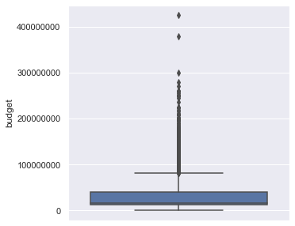

```python
plt.rcParams['figure.figsize'] = [5, 5]
sns.boxplot(y = 'budget', data = movies_profit)
plt.ticklabel_format(style='plain', axis='y');
```

The dataset seems to be heavily skewed by blockbusters with production budget > 100 mln. USD, while the main body of the dataset is sitting under $100 mln. It would be worthy to regroup movies by budget to evaluate average figures.

Now, let's investigate movies with budget <$100,000 to see how many outliers are there and if they can be fixed.

```python
smallest_budj = movies_profit.query('budget < 100000')
print('The number of movies with smallest budget + the number of columns',smallest_budj.shape)
smallest_budj
```

```
The number of movies with smallest budget + the number of columns (42, 13)
```

|  | id | original_title | director | budget | revenue | runtime | genres | release_date | vote_count | vote_average | budget_adj | revenue_adj | release_year |
| --- | --- | --- | --- | --- | --- | --- | --- | --- | --- | --- | --- | --- | --- |
| 1354 | 985 | Eraserhead | David Lynch | 10000 | 7000000 | 89 | Science Fiction\|Fantasy\|Horror\|Drama | 3/19/77 | 194 | 7.1 | 10000 | 2.518447e+07 | 1977 |
| 1733 | 22717 | Wanted | Prabhu Deva | 75 | 134 | 129 | Action\|Comedy\|Crime\|Thriller | 9/18/09 | 18 | 4.9 | 75 | 1.361977e+02 | 2009 |
| 1871 | 42151 | Down Terrace | Ben Wheatley | 31192 | 10000 | 89 | Drama\|Action\|Comedy | 9/1/09 | 15 | 6.5 | 31192 | 1.016400e+04 | 2009 |
| 2207 | 42296 | Catfish | Henry Joost\|Ariel Schulman | 30000 | 3045943 | 87 | Documentary | 9/17/10 | 125 | 6.4 | 30000 | 3.045943e+06 | 2010 |
| 2227 | 38568 | Howl | Rob Epstein\|Jeffrey Friedman | 30000 | 617000 | 84 | Drama | 8/26/10 | 45 | 6.8 | 30000 | 6.170000e+05 | 2010 |
| 2398 | 39356 | Boy | Taika Waititi | 3 | 43 | 87 | Drama\|Comedy | 2/14/10 | 26 | 7.3 | 3 | 4.300000e+01 | 2010 |
| 2449 | 2667 | The Blair Witch Project | Daniel Myrick\|Eduardo Sánchez | 25000 | 248000000 | 81 | Horror\|Mystery | 7/14/99 | 522 | 6.3 | 25000 | 3.246451e+08 | 1999 |
| 2519 | 10397 | Angela's Ashes | Alan Parker | 25 | 13 | 145 | Drama | 12/25/99 | 24 | 7.0 | 25 | 1.701769e+01 | 1999 |
| 2618 | 39964 | Lost & Found | Jeff Pollack | 1 | 100 | 95 | Comedy\|Romance | 4/23/99 | 14 | 4.8 | 1 | 1.309053e+02 | 1999 |
| 3581 | 59296 | Love, Wedding, Marriage | Dermot Mulroney | 1 | 1378 | 90 | Comedy\|Romance | 6/3/11 | 55 | 5.3 | 1 | 1.335831e+03 | 2011 |
| 3608 | 50217 | From Prada to Nada | Angel Gracia | 93 | 2500000 | 107 | Comedy\|Drama\|Romance | 1/28/11 | 47 | 5.2 | 93 | 2.423495e+06 | 2011 |
| 3755 | 79120 | Weekend | Andrew Haigh | 8000 | 469947 | 96 | Drama\|Romance | 9/22/11 | 96 | 7.4 | 8000 | 4.555657e+05 | 2011 |
| 3785 | 58699 | Bellflower | Evan Glodell | 17000 | 101236 | 106 | Action\|Drama\|Romance | 4/16/11 | 24 | 6.7 | 17000 | 9.813798e+04 | 2011 |
| 3798 | 66150 | Life in a Day | Kevin Macdonald\|Zillah Bowes | 45202 | 225861 | 95 | Documentary\|Drama | 1/27/11 | 58 | 7.3 | 45202 | 2.189492e+05 | 2011 |
| 3853 | 62796 | William & Kate | Mark Rosman | 20 | 15 | 83 | Drama\|Romance | 4/18/11 | 18 | 5.9 | 20 | 1.454097e+01 | 2011 |
| 3968 | 4614 | The Sum of All Fears | Phil Alden Robinson | 68 | 193 | 124 | Thriller\|Action\|Drama | 5/31/02 | 256 | 5.7 | 68 | 2.339664e+02 | 2002 |
| 4176 | 29047 | The Kid Stays in the Picture | Nanette Burstein\|Brett Morgen | 40000 | 1434436 | 93 | Documentary | 1/18/02 | 10 | 7.4 | 40000 | 1.738911e+06 | 2002 |
| 4192 | 2292 | Clerks | Kevin Smith | 27000 | 3151130 | 92 | Comedy | 9/13/94 | 383 | 7.2 | 27000 | 4.635664e+06 | 1994 |
| 4675 | 63574 | Joyful Noise | Todd Graff | 25 | 30 | 117 | Comedy\|Music | 1/13/12 | 25 | 6.7 | 25 | 2.849233e+01 | 2012 |
| 5162 | 24914 | Kid's Story | Shinichiro Watanabe | 10 | 5 | 15 | Science Fiction\|Animation | 6/2/03 | 16 | 6.8 | 10 | 5.926763e+00 | 2003 |
| 5785 | 212769 | Make Your Move | Duane Adler | 15 | 122 | 110 | Music | 8/7/13 | 20 | 5.9 | 15 | 1.141961e+02 | 2013 |
| 5852 | 217708 | Hross í oss | Benedikt Erlingsson | 10 | 11 | 85 | Drama\|Romance\|Comedy | 8/30/13 | 11 | 6.5 | 10 | 1.029637e+01 | 2013 |
| 6179 | 11338 | Into the Night | John Landis | 114 | 6700000 | 115 | Comedy\|Drama\|Thriller | 2/15/85 | 24 | 6.1 | 114 | 1.358201e+07 | 1985 |
| 6945 | 13484 | The Foot Fist Way | Jody Hill | 79000 | 245000 | 85 | Comedy | 6/24/06 | 19 | 5.3 | 79000 | 2.650089e+05 | 2006 |
| 7044 | 14337 | Primer | Shane Carruth | 7000 | 424760 | 79 | Science Fiction\|Drama\|Thriller | 10/8/04 | 341 | 6.9 | 7000 | 4.903622e+05 | 2004 |
| 7166 | 26579 | The Heart is Deceitful Above All Things | Asia Argento | 74050 | 176153 | 98 | Drama | 9/15/04 | 16 | 5.6 | 74050 | 2.033590e+05 | 2004 |
| 7178 | 9372 | Super Size Me | Morgan Spurlock | 65000 | 28575078 | 100 | Documentary\|Comedy\|Drama | 1/17/04 | 295 | 6.5 | 65000 | 3.298837e+07 | 2004 |
| 7277 | 692 | Pink Flamingos | John Waters | 12000 | 6000000 | 93 | Comedy | 3/12/72 | 51 | 6.3 | 12000 | 3.128737e+07 | 1972 |
| 7447 | 23827 | Paranormal Activity | Oren Peli | 15000 | 193355800 | 86 | Horror\|Mystery | 9/14/07 | 714 | 6.1 | 15000 | 2.033462e+08 | 2007 |
| 7685 | 13059 | The Signal | David Bruckner\|Dan Bush\|Jacob Gentry | 50000 | 249905 | 103 | Horror\|Action\|Thriller\|Science Fiction | 2/22/07 | 28 | 5.9 | 50000 | 2.628172e+05 | 2007 |
| 7813 | 22887 | Loose Change: Final Cut | Dylan Avery | 6000 | 6000 | 129 | Documentary | 11/11/07 | 12 | 5.1 | 6000 | 6.310011e+03 | 2007 |
| 8125 | 11980 | The Prophecy | Gregory Widen | 8 | 16 | 98 | Fantasy\|Horror\|Thriller | 9/1/95 | 54 | 5.5 | 8 | 2.289547e+01 | 1995 |
| 8235 | 25066 | Tales from the Hood | Rusty Cundieff | 6 | 11 | 98 | Horror\|Thriller | 5/24/95 | 13 | 5.1 | 6 | 1.574064e+01 | 1995 |
| 8944 | 14373 | Death Wish 2 | Michael Winner | 2 | 16 | 88 | Action\|Crime\|Thriller | 2/20/82 | 27 | 5.6 | 2 | 3.615428e+01 | 1982 |
| 9006 | 473 | Pi | Darren Aronofsky | 60000 | 3221152 | 84 | Mystery\|Drama\|Thriller | 7/10/98 | 286 | 6.9 | 60000 | 4.308920e+06 | 1998 |
| 9762 | 30497 | The Texas Chain Saw Massacre | Tobe Hooper | 85000 | 30859000 | 83 | Horror\|Thriller | 10/1/74 | 249 | 6.8 | 85000 | 1.364673e+08 | 1974 |
| 9992 | 1669 | The Hunt for Red October | John McTiernan | 30 | 200 | 134 | Action\|Adventure\|Thriller | 3/2/90 | 615 | 6.9 | 30 | 3.337797e+02 | 1990 |
| 10050 | 20701 | Tales from the Darkside: The Movie | John Harrison | 3 | 16 | 93 | Fantasy\|Horror\|Comedy | 5/3/90 | 37 | 5.8 | 3 | 2.670238e+01 | 1990 |
| 10236 | 1499 | Teenage Mutant Ninja Turtles III | Stuart Gillard | 21 | 42 | 96 | Action\|Adventure\|Comedy\|Family\|Fantasy | 3/17/93 | 95 | 5.2 | 21 | 6.339774e+01 | 1993 |
| 10297 | 9644 | National Lampoon's Loaded Weapon 1 | Gene Quintano | 8 | 27 | 84 | Comedy | 2/4/93 | 72 | 5.5 | 8 | 4.075569e+01 | 1993 |
| 10495 | 8856 | The Karate Kid, Part II | John G. Avildsen | 113 | 115103979 | 113 | Adventure\|Drama\|Action\|Romance\|Family | 6/18/86 | 211 | 5.8 | 113 | 2.289886e+08 | 1986 |
| 10777 | 28932 | F.I.S.T. | Norman Jewison | 11 | 11 | 145 | Drama\|Action | 4/26/78 | 13 | 6.7 | 11 | 3.676971e+01 | 1978 |

The dataset on films with small budget contained some true information, as well as some false data. For example, while 'Eraserhead' budget was 10,000 usd according to google (matches the dataset), whle the budget of next movie 'Wanted' was 350 mln INR, which is approx. $6.5 mln USD (source - https://g.co/kgs/U9ofL4) and isn't matching the provided data.

Therefore, we deal with a mixed bag of correct and incorrect data. In this case, let's replace the budget <5000 with median value in the dataset in order to maximise the number of filled cells.

```python
#assigning median value to movies with budget < 5,000 $USD and swapping the revenue

budget_median = movies_profit['budget'].median()
movies_profit['budget'].mask(movies_profit['budget'] < 5000, budget_median, inplace = True)

#let's not forget to apply the same procedure to adjusted budget for analysis

budget_adj_median = movies_profit['budget_adj'].median()
movies_profit['budget_adj'].mask(movies_profit['budget_adj'] < 5000, budget_adj_median, inplace = True)

#checking the dataset again
smallest_budj = movies_profit.query('budget < 100000')
print('The number of movies with smallest budget + the number of columns',smallest_budj.shape)
smallest_budj.sort_values(by = 'budget')
```

```
The number of movies with smallest budget + the number of columns (20, 13)
```

|  | id | original_title | director | budget | revenue | runtime | genres | release_date | vote_count | vote_average | budget_adj | revenue_adj | release_year |
| --- | --- | --- | --- | --- | --- | --- | --- | --- | --- | --- | --- | --- | --- |
| 7813 | 22887 | Loose Change: Final Cut | Dylan Avery | 6000 | 6000 | 129 | Documentary | 11/11/07 | 12 | 5.1 | 6000 | 6.310011e+03 | 2007 |
| 7044 | 14337 | Primer | Shane Carruth | 7000 | 424760 | 79 | Science Fiction\|Drama\|Thriller | 10/8/04 | 341 | 6.9 | 7000 | 4.903622e+05 | 2004 |
| 3755 | 79120 | Weekend | Andrew Haigh | 8000 | 469947 | 96 | Drama\|Romance | 9/22/11 | 96 | 7.4 | 8000 | 4.555657e+05 | 2011 |
| 1354 | 985 | Eraserhead | David Lynch | 10000 | 7000000 | 89 | Science Fiction\|Fantasy\|Horror\|Drama | 3/19/77 | 194 | 7.1 | 10000 | 2.518447e+07 | 1977 |
| 7277 | 692 | Pink Flamingos | John Waters | 12000 | 6000000 | 93 | Comedy | 3/12/72 | 51 | 6.3 | 12000 | 3.128737e+07 | 1972 |
| 7447 | 23827 | Paranormal Activity | Oren Peli | 15000 | 193355800 | 86 | Horror\|Mystery | 9/14/07 | 714 | 6.1 | 15000 | 2.033462e+08 | 2007 |
| 3785 | 58699 | Bellflower | Evan Glodell | 17000 | 101236 | 106 | Action\|Drama\|Romance | 4/16/11 | 24 | 6.7 | 17000 | 9.813798e+04 | 2011 |
| 2449 | 2667 | The Blair Witch Project | Daniel Myrick\|Eduardo SÃ¡nchez | 25000 | 248000000 | 81 | Horror\|Mystery | 7/14/99 | 522 | 6.3 | 25000 | 3.246451e+08 | 1999 |
| 4192 | 2292 | Clerks | Kevin Smith | 27000 | 3151130 | 92 | Comedy | 9/13/94 | 383 | 7.2 | 27000 | 4.635664e+06 | 1994 |
| 2227 | 38568 | Howl | Rob Epstein\|Jeffrey Friedman | 30000 | 617000 | 84 | Drama | 8/26/10 | 45 | 6.8 | 30000 | 6.170000e+05 | 2010 |
| 2207 | 42296 | Catfish | Henry Joost\|Ariel Schulman | 30000 | 3045943 | 87 | Documentary | 9/17/10 | 125 | 6.4 | 30000 | 3.045943e+06 | 2010 |
| 1871 | 42151 | Down Terrace | Ben Wheatley | 31192 | 10000 | 89 | Drama\|Action\|Comedy | 9/1/09 | 15 | 6.5 | 31192 | 1.016400e+04 | 2009 |
| 4176 | 29047 | The Kid Stays in the Picture | Nanette Burstein\|Brett Morgen | 40000 | 1434436 | 93 | Documentary | 1/18/02 | 10 | 7.4 | 40000 | 1.738911e+06 | 2002 |
| 3798 | 66150 | Life in a Day | Kevin Macdonald\|Zillah Bowes | 45202 | 225861 | 95 | Documentary\|Drama | 1/27/11 | 58 | 7.3 | 45202 | 2.189492e+05 | 2011 |
| 7685 | 13059 | The Signal | David Bruckner\|Dan Bush\|Jacob Gentry | 50000 | 249905 | 103 | Horror\|Action\|Thriller\|Science Fiction | 2/22/07 | 28 | 5.9 | 50000 | 2.628172e+05 | 2007 |
| 9006 | 473 | Pi | Darren Aronofsky | 60000 | 3221152 | 84 | Mystery\|Drama\|Thriller | 7/10/98 | 286 | 6.9 | 60000 | 4.308920e+06 | 1998 |
| 7178 | 9372 | Super Size Me | Morgan Spurlock | 65000 | 28575078 | 100 | Documentary\|Comedy\|Drama | 1/17/04 | 295 | 6.5 | 65000 | 3.298837e+07 | 2004 |
| 7166 | 26579 | The Heart is Deceitful Above All Things | Asia Argento | 74050 | 176153 | 98 | Drama | 9/15/04 | 16 | 5.6 | 74050 | 2.033590e+05 | 2004 |
| 6945 | 13484 | The Foot Fist Way | Jody Hill | 79000 | 245000 | 85 | Comedy | 6/24/06 | 19 | 5.3 | 79000 | 2.650089e+05 | 2006 |
| 9762 | 30497 | The Texas Chain Saw Massacre | Tobe Hooper | 85000 | 30859000 | 83 | Horror\|Thriller | 10/1/74 | 249 | 6.8 | 85000 | 1.364673e+08 | 1974 |

As we can see now, movies with budget less than 5,000 USD are now successfully replaced with median value.

Now let's investigate the part of the dataset with the budget > 100,000,000 USD.

```python
movies_profit.query('budget > 100000000').sort_values(by = 'budget')
```

|  | id | original_title | director | budget | revenue | runtime | genres | release_date | vote_count | vote_average | budget_adj | revenue_adj | release_year |
| --- | --- | --- | --- | --- | --- | --- | --- | --- | --- | --- | --- | --- | --- |
| 3921 | 180 | Minority Report | Steven Spielberg | 102000000 | 358372926 | 145 | Action\|Thriller\|Science Fiction\|Mystery | 6/20/02 | 1595 | 6.9 | 102000000 | 4.344417e+08 | 2002 |
| 4384 | 83542 | Cloud Atlas | Lilly Wachowski\|Lana Wachowski\|Tom Tykwer | 102000000 | 130482868 | 172 | Drama\|Science Fiction | 10/26/12 | 2162 | 6.5 | 102000000 | 1.239254e+08 | 2012 |
| 2671 | 9705 | Swordfish | Dominic Sena | 102000000 | 147080413 | 99 | Action\|Crime\|Thriller | 6/7/01 | 606 | 6.0 | 102000000 | 1.811278e+08 | 2001 |
| 712 | 172385 | Rio 2 | Carlos Saldanha | 103000000 | 500188435 | 102 | Animation\|Adventure\|Comedy\|Family | 3/19/14 | 659 | 6.5 | 103000000 | 4.607191e+08 | 2014 |
| 8661 | 98 | Gladiator | Ridley Scott | 103000000 | 457640427 | 155 | Action\|Drama\|Adventure | 5/1/00 | 3531 | 7.7 | 103000000 | 5.795065e+08 | 2000 |
| ... | ... | ... | ... | ... | ... | ... | ... | ... | ... | ... | ... | ... | ... |
| 6570 | 1452 | Superman Returns | Bryan Singer | 270000000 | 391081192 | 154 | Adventure\|Fantasy\|Action\|Science Fiction | 6/28/06 | 834 | 5.3 | 270000000 | 4.230205e+08 | 2006 |
| 14 | 99861 | Avengers: Age of Ultron | Joss Whedon | 280000000 | 1405035767 | 141 | Action\|Adventure\|Science Fiction | 4/22/15 | 4304 | 7.4 | 280000000 | 1.292632e+09 | 2015 |
| 7387 | 285 | Pirates of the Caribbean: At World's End | Gore Verbinski | 300000000 | 961000000 | 169 | Adventure\|Fantasy\|Action | 5/19/07 | 2626 | 6.8 | 300000000 | 1.010654e+09 | 2007 |
| 3375 | 1865 | Pirates of the Caribbean: On Stranger Tides | Rob Marshall | 380000000 | 1021683000 | 136 | Adventure\|Action\|Fantasy | 5/11/11 | 3180 | 6.3 | 380000000 | 9.904175e+08 | 2011 |
| 2244 | 46528 | The Warrior's Way | Sngmoo Lee | 425000000 | 11087569 | 100 | Adventure\|Fantasy\|Action\|Western\|Thriller | 12/2/10 | 74 | 6.4 | 425000000 | 1.108757e+07 | 2010 |

279 rows × 13 columns

As we assumed initially, all of the above movies are blockbusters made with big directors and huge budgets. Therefore, the given information is likely to be true.

Now, let's have a look if there's an opportunity to fix the revenue. First, look at the data distribution.

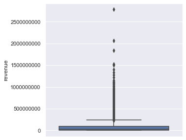

```python
plt.rcParams['figure.figsize'] = [5, 5]
sns.boxplot(y = 'revenue', data = movies_profit)
plt.ticklabel_format(style='plain', axis='y');
```

As it is seen on the chart, some movies could generate zero revenue, and the dataset is quite stretched by the number of outliers (blockbusters) in comparison with main body.

Let's have a look into how many movie titles have near-zero revenue and see if there's any error that could be discovered.

While it is too hard to judge if blockbusters box office true or not, there is an opportunity to look into too small values to get the understanging if values are true or not.

```python
movies_profit.query('revenue < 1000').sort_values(by = 'revenue')
```

|  | id | original_title | director | budget | revenue | runtime | genres | release_date | vote_count | vote_average | budget_adj | revenue_adj | release_year |
| --- | --- | --- | --- | --- | --- | --- | --- | --- | --- | --- | --- | --- | --- |
| 8142 | 2293 | Mallrats | Kevin Smith | 6000000 | 2 | 94 | Romance\|Comedy | 10/20/95 | 201 | 6.8 | 6000000 | 2.861934 | 1995 |
| 5067 | 13537 | Shattered Glass | Billy Ray | 6000000 | 2 | 94 | Drama\|History | 11/14/03 | 46 | 6.4 | 6000000 | 2.370705 | 2003 |
| 1380 | 18196 | The Sentinel | Michael Winner | 17000000 | 3 | 92 | Horror\|Drama\|Mystery | 1/7/77 | 14 | 6.3 | 17000000 | 10.793343 | 1977 |
| 3239 | 14301 | Dr. Horrible's Sing-Along Blog | Joss Whedon | 200000 | 3 | 42 | Adventure\|Action\|Comedy\|Science Fiction\|Music | 7/15/08 | 140 | 7.7 | 200000 | 3.038360 | 2008 |
| 10607 | 12101 | Soylent Green | Richard Fleischer | 17000000 | 3 | 97 | Mystery\|Science Fiction\|Thriller | 4/19/73 | 124 | 6.6 | 17000000 | 14.733479 | 1973 |
| 8523 | 9431 | Bordello of Blood | Gilbert Adler | 15000000 | 5 | 87 | Horror\|Comedy | 8/16/96 | 27 | 4.9 | 15000000 | 6.951084 | 1996 |
| 5162 | 24914 | Kid's Story | Shinichiro Watanabe | 17000000 | 5 | 15 | Science Fiction\|Animation | 6/2/03 | 16 | 6.8 | 17000000 | 5.926763 | 2003 |
| 10307 | 2259 | The House of the Spirits | Bille August | 25000000 | 6 | 140 | Romance\|Drama | 10/19/93 | 52 | 6.7 | 25000000 | 9.056820 | 1993 |
| 8226 | 48781 | Never Talk to Strangers | Peter Hall | 6400000 | 6 | 86 | Thriller\|Romance | 10/20/95 | 15 | 4.5 | 6400000 | 8.585801 | 1995 |
| 8328 | 16219 | Gladiator | Rowdy Herrington | 17000000 | 9 | 101 | Action\|Drama | 3/6/92 | 10 | 5.1 | 17000000 | 13.986218 | 1992 |
| 3283 | 53955 | Parlami D'Amore | Silvio Muccino | 17000000 | 9 | 109 | Comedy\|Romance | 2/14/08 | 11 | 5.1 | 17000000 | 9.115080 | 2008 |
| 2252 | 56272 | Elektra Luxx | Sebastian Gutierrez | 17000000 | 10 | 98 | Action\|Comedy\|Drama | 3/14/10 | 23 | 4.2 | 17000000 | 10.000000 | 2010 |
| 8235 | 25066 | Tales from the Hood | Rusty Cundieff | 17000000 | 11 | 98 | Horror\|Thriller | 5/24/95 | 13 | 5.1 | 17000000 | 15.740636 | 1995 |
| 5852 | 217708 | Hross í oss | Benedikt Erlingsson | 17000000 | 11 | 85 | Drama\|Romance\|Comedy | 8/30/13 | 11 | 6.5 | 17000000 | 10.296367 | 2013 |
| 10777 | 28932 | F.I.S.T. | Norman Jewison | 17000000 | 11 | 145 | Drama\|Action | 4/26/78 | 13 | 6.7 | 17000000 | 36.769708 | 1978 |
| 7158 | 14844 | Chasing Liberty | Andy Cadiff | 23000000 | 12 | 111 | Comedy\|Romance | 1/9/04 | 86 | 6.2 | 23000000 | 13.853345 | 2004 |
| 2519 | 10397 | Angela's Ashes | Alan Parker | 17000000 | 13 | 145 | Drama | 12/25/99 | 24 | 7.0 | 17000000 | 17.017687 | 1999 |
| 9390 | 10379 | Drop Dead Fred | Ate de Jong | 17000000 | 13 | 103 | Comedy\|Fantasy\|Family | 4/19/91 | 38 | 6.0 | 17000000 | 20.814207 | 1991 |
| 10294 | 10285 | Jason Goes to Hell: The Final Friday | Adam Marcus | 3000000 | 15 | 87 | Horror\|Thriller | 8/13/93 | 86 | 3.9 | 3000000 | 22.642049 | 1993 |
| 9109 | 17915 | Dance With Me | Randa Haines | 17000000 | 15 | 126 | Drama\|Romance\|Music | 8/21/98 | 16 | 5.7 | 17000000 | 20.065432 | 1998 |
| 3853 | 62796 | William & Kate | Mark Rosman | 17000000 | 15 | 83 | Drama\|Romance | 4/18/11 | 18 | 5.9 | 17000000 | 14.540971 | 2011 |
| 10050 | 20701 | Tales from the Darkside: The Movie | John Harrison | 17000000 | 16 | 93 | Fantasy\|Horror\|Comedy | 5/3/90 | 37 | 5.8 | 17000000 | 26.702377 | 1990 |
| 8944 | 14373 | Death Wish 2 | Michael Winner | 17000000 | 16 | 88 | Action\|Crime\|Thriller | 2/20/82 | 27 | 5.6 | 17000000 | 36.154278 | 1982 |
| 8125 | 11980 | The Prophecy | Gregory Widen | 17000000 | 16 | 98 | Fantasy\|Horror\|Thriller | 9/1/95 | 54 | 5.5 | 17000000 | 22.895470 | 1995 |
| 10045 | 17009 | Jetsons: The Movie | Joseph Barbera\|William Hanna | 17000000 | 20 | 82 | Animation\|Comedy\|Family\|Science Fiction | 6/6/90 | 22 | 5.8 | 17000000 | 33.377971 | 1990 |
| 5060 | 10944 | In the Cut | Jane Campion | 12000000 | 23 | 119 | Thriller\|Mystery | 9/9/03 | 36 | 4.7 | 12000000 | 27.263111 | 2003 |
| 10297 | 9644 | National Lampoon's Loaded Weapon 1 | Gene Quintano | 17000000 | 27 | 84 | Comedy | 2/4/93 | 72 | 5.5 | 17000000 | 40.755689 | 1993 |
| 9401 | 10174 | Madonna: Truth or Dare | Alek Keshishian\|Mark Aldo Miceli | 17000000 | 29 | 114 | Documentary\|Music | 5/10/91 | 12 | 6.8 | 17000000 | 46.431692 | 1991 |
| 4675 | 63574 | Joyful Noise | Todd Graff | 17000000 | 30 | 117 | Comedy\|Music | 1/13/12 | 25 | 6.7 | 17000000 | 28.492328 | 2012 |
| 7901 | 9730 | Friday the 13th: The Final Chapter | Joseph Zito | 17000000 | 32 | 91 | Horror\|Thriller | 4/13/84 | 100 | 5.7 | 17000000 | 67.169345 | 1984 |
| 8599 | 13997 | Black Sheep | Penelope Spheeris | 17000000 | 32 | 87 | Comedy | 2/1/96 | 50 | 6.3 | 17000000 | 44.486936 | 1996 |
| 10236 | 1499 | Teenage Mutant Ninja Turtles III | Stuart Gillard | 17000000 | 42 | 96 | Action\|Adventure\|Comedy\|Family\|Fantasy | 3/17/93 | 95 | 5.2 | 17000000 | 63.397738 | 1993 |
| 2398 | 39356 | Boy | Taika Waititi | 17000000 | 43 | 87 | Drama\|Comedy | 2/14/10 | 26 | 7.3 | 17000000 | 43.000000 | 2010 |
| 7506 | 2196 | Death at a Funeral | Frank Oz | 9000000 | 46 | 90 | Comedy\|Drama | 2/9/07 | 262 | 6.7 | 9000000 | 48.376755 | 2007 |
| 9332 | 1497 | Teenage Mutant Ninja Turtles II: The Secret of... | Michael Pressman | 25000000 | 78 | 88 | Science Fiction\|Adventure\|Action\|Comedy\|Family | 3/22/91 | 161 | 6.0 | 25000000 | 124.885242 | 1991 |
| 1900 | 47813 | Waking Sleeping Beauty | Don Hahn | 17000000 | 80 | 86 | Documentary\|Family | 9/5/09 | 11 | 6.9 | 17000000 | 81.312035 | 2009 |
| 6011 | 192133 | Jimi: All Is by My Side | John Ridley | 17000000 | 97 | 118 | Drama\|Music | 9/8/13 | 40 | 5.3 | 17000000 | 90.795235 | 2013 |
| 2618 | 39964 | Lost & Found | Jeff Pollack | 17000000 | 100 | 95 | Comedy\|Romance | 4/23/99 | 14 | 4.8 | 17000000 | 130.905285 | 1999 |
| 5785 | 212769 | Make Your Move | Duane Adler | 17000000 | 122 | 110 | Music | 8/7/13 | 20 | 5.9 | 17000000 | 114.196069 | 2013 |
| 5777 | 137563 | A Band Called Death | Mark Christopher Covino\|Jeff Howlett | 17000000 | 125 | 96 | Documentary\|Music | 6/27/13 | 28 | 7.1 | 17000000 | 117.004169 | 2013 |
| 1733 | 22717 | Wanted | Prabhu Deva | 17000000 | 134 | 129 | Action\|Comedy\|Crime\|Thriller | 9/18/09 | 18 | 4.9 | 17000000 | 136.197658 | 2009 |
| 6707 | 9986 | Charlotte's Web | Gary Winick | 85000000 | 144 | 97 | Comedy\|Family\|Fantasy | 12/15/06 | 161 | 6.0 | 85000000 | 155.760359 | 2006 |
| 3968 | 4614 | The Sum of All Fears | Phil Alden Robinson | 17000000 | 193 | 124 | Thriller\|Action\|Drama | 5/31/02 | 256 | 5.7 | 17000000 | 233.966449 | 2002 |
| 9992 | 1669 | The Hunt for Red October | John McTiernan | 17000000 | 200 | 134 | Action\|Adventure\|Thriller | 3/2/90 | 615 | 6.9 | 17000000 | 333.779708 | 1990 |
| 5834 | 156268 | InAPPropriate Comedy | Vince Offer | 17000000 | 228 | 84 | Comedy | 3/22/13 | 16 | 3.2 | 17000000 | 213.415604 | 2013 |
| 9580 | 41965 | Paperhouse | Bernard Rose | 17000000 | 241 | 92 | Drama\|Fantasy\|Horror | 1/1/88 | 12 | 5.5 | 17000000 | 444.377737 | 1988 |
| 4970 | 10009 | Brother Bear | Aaron Blaise\|Robert Walker | 100000000 | 250 | 85 | Animation\|Adventure\|Family\|Fantasy | 10/20/03 | 753 | 6.8 | 100000000 | 296.338161 | 2003 |
| 4682 | 94204 | Meeting Evil | Chris Fisher | 17000000 | 525 | 89 | Crime\|Drama\|Mystery\|Thriller | 5/3/12 | 29 | 4.4 | 17000000 | 498.615748 | 2012 |
| 5669 | 192538 | Hammer of the Gods | Farren Blackburn | 17000000 | 641 | 99 | History\|Action\|Adventure | 7/5/13 | 79 | 4.3 | 17000000 | 599.997379 | 2013 |
| 4665 | 78215 | Into the White | Petter Næss | 17000000 | 704 | 100 | Action\|Drama | 3/6/12 | 44 | 6.5 | 17000000 | 668.619974 | 2012 |
| 5637 | 207768 | I Spit on Your Grave 2 | Steven R. Monroe | 17000000 | 809 | 106 | Thriller\|Horror\|Crime | 8/25/13 | 162 | 5.9 | 17000000 | 757.250982 | 2013 |

After looking into smallest and largest values it becomes clear that movies with revenue <100 were given numbers in mln dollars.

##### Smallest revenue movies:

Shattered Glass: 2,9 mln. usd, [proof](https://g.co/kgs/DkjKXM)

Mallrats: 2,1 mln. usd, [proof](https://g.co/kgs/prZwZx)

Bordello of Blood: 5.6 mln. usd, [proof](https://g.co/kgs/7kwS2A)

Death at the funeral: 46.8 mln. usd, [proof](https://g.co/kgs/Gy1YWV)

Therefore, such small numbers are given in mln dollars. To fix it, it is needed to index these values to be on parity with current value.

```python
#indexing values below 1000 revenue by 1000000
movies_profit['revenue'].mask(movies_profit['revenue'] < 1000, movies_profit['revenue']*1000000, inplace = True)

#applying the same approach to revenue_adj
movies_profit['revenue_adj'].mask(movies_profit['revenue_adj'] < 1000, movies_profit['revenue_adj']*1000000, inplace = True)

#checking if the indexing was correct
movies_profit.query('original_title == "Mallrats"')
```

|  | id | original_title | director | budget | revenue | runtime | genres | release_date | vote_count | vote_average | budget_adj | revenue_adj | release_year |
| --- | --- | --- | --- | --- | --- | --- | --- | --- | --- | --- | --- | --- | --- |
| 8142 | 2293 | Mallrats | Kevin Smith | 6000000 | 2000000 | 94 | Romance\|Comedy | 10/20/95 | 201 | 6.8 | 6000000 | 2.861934e+06 | 1995 |

```python
movies_profit['profit_adj'] = movies_profit['revenue_adj'] - movies_profit['budget_adj'];
movies_profit.head()
```

|  | id | original_title | director | budget | revenue | runtime | genres | release_date | vote_count | vote_average | budget_adj | revenue_adj | release_year | profit_adj |
| --- | --- | --- | --- | --- | --- | --- | --- | --- | --- | --- | --- | --- | --- | --- |
| 0 | 135397 | Jurassic World | Colin Trevorrow | 150000000 | 1513528810 | 124 | Action\|Adventure\|Science Fiction\|Thriller | 6/9/15 | 5562 | 6.5 | 150000000 | 1.392446e+09 | 2015 | 1.242446e+09 |
| 1 | 76341 | Mad Max: Fury Road | George Miller | 150000000 | 378436354 | 120 | Action\|Adventure\|Science Fiction\|Thriller | 5/13/15 | 6185 | 7.1 | 150000000 | 3.481613e+08 | 2015 | 1.981613e+08 |
| 2 | 262500 | Insurgent | Robert Schwentke | 110000000 | 295238201 | 119 | Adventure\|Science Fiction\|Thriller | 3/18/15 | 2480 | 6.3 | 110000000 | 2.716190e+08 | 2015 | 1.616190e+08 |
| 3 | 140607 | Star Wars: The Force Awakens | J.J. Abrams | 200000000 | 2068178225 | 136 | Action\|Adventure\|Science Fiction\|Fantasy | 12/15/15 | 5292 | 7.5 | 200000000 | 1.902723e+09 | 2015 | 1.702723e+09 |
| 4 | 168259 | Furious 7 | James Wan | 190000000 | 1506249360 | 137 | Action\|Crime\|Thriller | 4/1/15 | 2947 | 7.3 | 190000000 | 1.385749e+09 | 2015 | 1.195749e+09 |

#### Fixing date and year fields before proceeding with exploratory data analysis

```python
movies_profit.dtypes
```

```
id                  int64
original_title     object
director           object
budget              int64
revenue             int64
runtime             int64
genres             object
release_date       object
vote_count          int64
vote_average      float64
budget_adj          int64
revenue_adj       float64
release_year        int64
profit_adj        float64
dtype: object
```

Let's use datetime package for date and year transformation

```python
#transforming release_date into datetime column

movies_profit['release_date'] = pd.to_datetime(movies_profit['release_date'], format= '%m/%d/%y')
movies_profit['release_date'] = movies_profit['release_date'].apply(lambda x: x if x<datetime.now() else date(x.year-100,x.month,x.day))
```

Looking into the dataframe last time before starting the analysis - everything looks good, and we can start the analysis to answer questions.

It's ok to have negative profits, as not all movies are end up being profitable, right?

```python
movies_profit.describe()
```

|  | id | budget | revenue | runtime | vote_count | vote_average | budget_adj | revenue_adj | release_year | profit_adj |
| --- | --- | --- | --- | --- | --- | --- | --- | --- | --- | --- |
| count | 4848.000000 | 4.848000e+03 | 4.848000e+03 | 4848.000000 | 4848.000000 | 4848.000000 | 4.848000e+03 | 4.848000e+03 | 4848.000000 | 4.848000e+03 |
| mean | 44581.495875 | 3.314106e+07 | 9.033214e+07 | 107.958746 | 436.370875 | 6.149072 | 3.314106e+07 | 1.163177e+08 | 2000.918317 | 8.317662e+07 |
| std | 72375.117496 | 3.845538e+07 | 1.628951e+08 | 21.106046 | 806.545807 | 0.798774 | 3.845538e+07 | 1.993526e+08 | 11.570397 | 1.811604e+08 |
| min | 5.000000 | 6.000000e+03 | 1.081000e+03 | 15.000000 | 10.000000 | 2.100000 | 6.000000e+03 | 1.026674e+03 | 1960.000000 | -4.139124e+08 |
| 25% | 8283.500000 | 1.300000e+07 | 8.196562e+06 | 95.000000 | 46.000000 | 5.600000 | 1.300000e+07 | 1.126157e+07 | 1994.000000 | -3.824873e+06 |
| 50% | 12153.500000 | 1.700000e+07 | 3.237796e+07 | 104.000000 | 147.000000 | 6.200000 | 1.700000e+07 | 4.477392e+07 | 2004.000000 | 2.130486e+07 |
| 75% | 43971.500000 | 4.000000e+07 | 1.005576e+08 | 117.000000 | 435.000000 | 6.700000 | 4.000000e+07 | 1.333610e+08 | 2010.000000 | 9.279249e+07 |
| max | 417859.000000 | 4.250000e+08 | 2.781506e+09 | 705.000000 | 9767.000000 | 8.400000 | 4.250000e+08 | 2.827124e+09 | 2015.000000 | 2.778712e+09 |

## Exploratory Data Analysis

### Research question 1: What genres usually generate more revenue? Does the genre that ends up high-revenue one remains the most profitable?

To do the etimation, we need to breakdown genres and create duplicates for further aggregation.

```python
#Breaking down the dataset by genre

s = movies_profit['genres'].str.split('|', expand = True).stack()
i = s.index.get_level_values(0)
df_gen = movies_profit.loc[i].copy()
df_gen['genres'] = s.values
```

From previous part of the analysis we knew that budget and profitability are largely driven by blockbusters. Therefore, let's compare the data using median values.

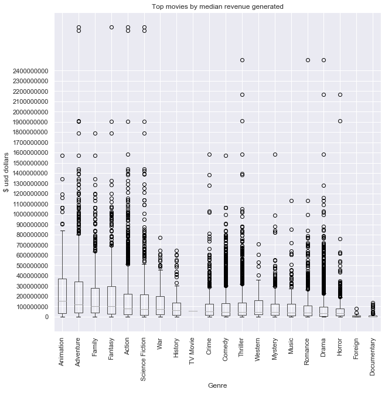

```python
#Building boxplot

def boxplot_sorted(df, by, column):
  df2 = pd.DataFrame({col:vals[column] for col, vals in df.groupby(by)})
  meds = df2.median().sort_values(ascending = False)
  df2[meds.index].boxplot(rot=90)


plt.rcParams['figure.figsize'] = [10, 10]
plt.ticklabel_format(style='plain', axis='y')
plt.yticks(np.arange(0,2500000000, 100000000))
plt.title('Top movies by median revenue generated')
plt.xlabel('Genre')
plt.ylabel('$ usd dollars')
boxplot_sorted(df_gen, by=["genres"], column="revenue_adj")
```

Let's see if the same genre would remain the most profitable.

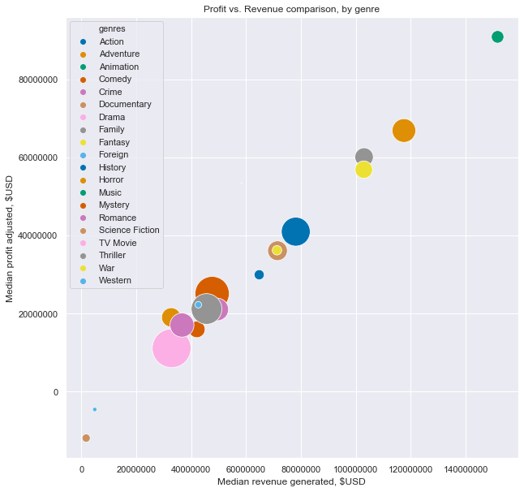

```python
#Building the chart representing most revenue-generating genres

gen_agg = df_gen.groupby(['genres'], as_index = False).median()
areas = df_gen.groupby(['genres']).size()

ax = sns.scatterplot(x='revenue_adj', y = 'profit_adj', hue = 'genres', data = gen_agg, s = areas, palette = 'colorblind')
plt.ticklabel_format(style='plain', axis='y');
plt.ticklabel_format(style='plain', axis='x');
plt.ylabel('Median profit adjusted, $USD')
plt.xlabel('Median revenue generated, $USD')
plt.title('Profit vs. Revenue comparison, by genre');
```

Interesting! Suprisingly, animation is the most profitable-driving genre from the median perspective, followed by Adventure and Family movies!

That means that potentially we can conclude that in order to increase chances to gain high profits, movie producers should aim towards these genres.

### Research question 2: How much it cost to product a movie in average - per genre?

To answer this question, let's keep working on the same dataset and build another boxplot.

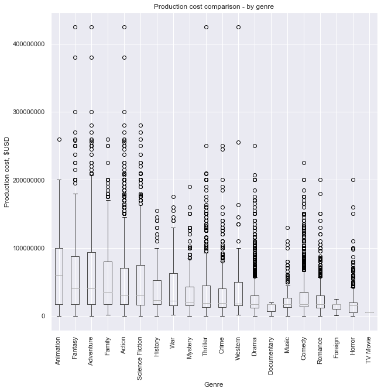

```python
plt.rcParams['figure.figsize'] = [10, 10]
boxplot_sorted(df_gen, by=["genres"], column="budget_adj")
plt.ticklabel_format(style='plain', axis='y');
plt.ylabel('Production cost, $USD')
plt.xlabel('Genre')
plt.title('Production cost comparison - by genre');
```

Well, even though Animation seems to be the safest bet to generate the revenue based on the number of observations available, it might be hard to start from this genre, as production costs would be over 50 mln. dollars.

Based on this, we can conclude that TV-Movie or Horror/Romance/Comedy be easier to start with as a young producer.

### Research question 3: How the average production cost been changing over years?

To answer this question, let's group available data by year of production and build a timeline chart with median value.

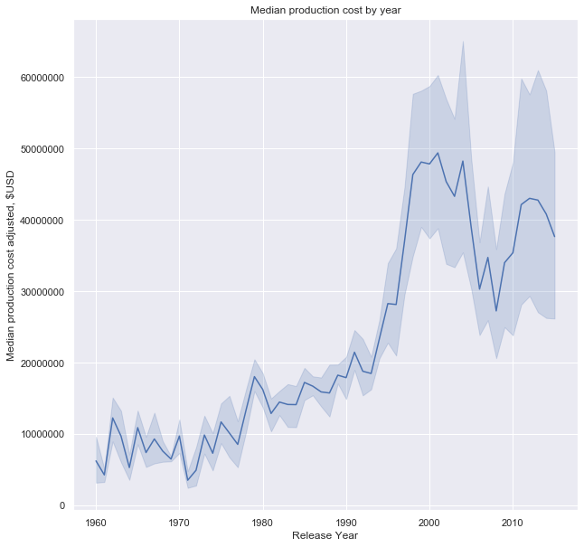

```python
gen_time_agg = df_gen.groupby(['genres','release_year'], as_index = False).median()
plt.ticklabel_format(style='plain', axis='y');
ax = sns.lineplot(x='release_year', y = 'budget_adj', data = gen_time_agg, markers = True)
plt.ylabel('Median production cost adjusted, $USD')
plt.xlabel('Release Year')
plt.title('Median production cost by year');
```

It is interesting to see how production costs are fluctuating over time! Basically, we can see that movie production cost was building up towards millenum and skyrocketed between 1990 and 2000. However, after costs started to go down (possibly due to piracy problems?), and later we can see the impact of 2008 recession.

However, production costs went up right after.

#### 3.1 Changes in production cost - per genre

Let's have a look at how production cost was changing over time.

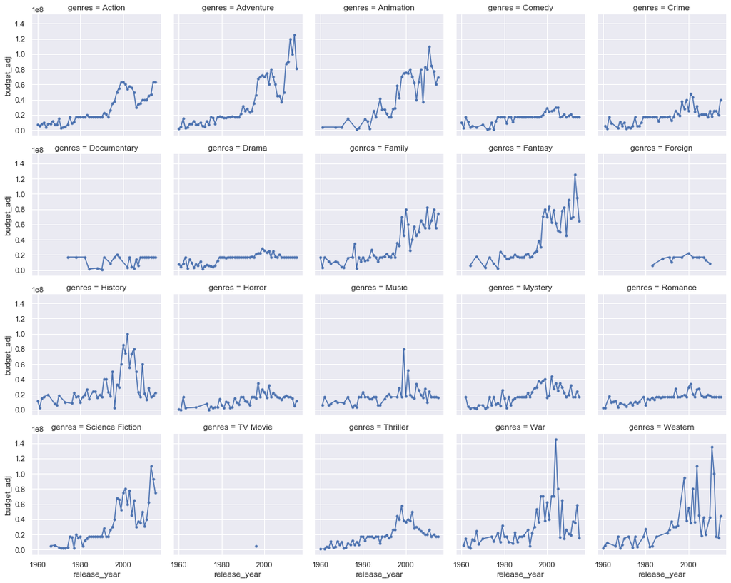

```python
g = sns.FacetGrid(gen_time_agg, col = 'genres', col_wrap = 5)
g = g.map(plt.plot, 'release_year', 'budget_adj', marker = '.')
```

Production cost by genre was fluctuating with some of genres, and was more stable with others. For example, production costs for genres like Action, Adventure and Animation was growing quite significantly, while for genres like Horror or Romance production cost was relatively stable and didn't change much.

Also, genres like thriller became cheaper to produce over time.

### Research question 4: How the average movie profit changed over time for movies with high, medium and low production costs?

This question requires additional categorisation. To do this, let's get back to original clean dataset without duplicated genres and categorize all production costs as high/medium/low before plotting.

```python
movies_profit.describe()
```

|  | id | budget | revenue | runtime | vote_count | vote_average | budget_adj | revenue_adj | release_year | profit_adj |
| --- | --- | --- | --- | --- | --- | --- | --- | --- | --- | --- |
| count | 4848.000000 | 4.848000e+03 | 4.848000e+03 | 4848.000000 | 4848.000000 | 4848.000000 | 4.848000e+03 | 4.848000e+03 | 4848.000000 | 4.848000e+03 |
| mean | 44581.495875 | 3.314106e+07 | 9.033214e+07 | 107.958746 | 436.370875 | 6.149072 | 3.314106e+07 | 1.163177e+08 | 2000.918317 | 8.317662e+07 |
| std | 72375.117496 | 3.845538e+07 | 1.628951e+08 | 21.106046 | 806.545807 | 0.798774 | 3.845538e+07 | 1.993526e+08 | 11.570397 | 1.811604e+08 |
| min | 5.000000 | 6.000000e+03 | 1.081000e+03 | 15.000000 | 10.000000 | 2.100000 | 6.000000e+03 | 1.026674e+03 | 1960.000000 | -4.139124e+08 |
| 25% | 8283.500000 | 1.300000e+07 | 8.196562e+06 | 95.000000 | 46.000000 | 5.600000 | 1.300000e+07 | 1.126157e+07 | 1994.000000 | -3.824873e+06 |
| 50% | 12153.500000 | 1.700000e+07 | 3.237796e+07 | 104.000000 | 147.000000 | 6.200000 | 1.700000e+07 | 4.477392e+07 | 2004.000000 | 2.130486e+07 |
| 75% | 43971.500000 | 4.000000e+07 | 1.005576e+08 | 117.000000 | 435.000000 | 6.700000 | 4.000000e+07 | 1.333610e+08 | 2010.000000 | 9.279249e+07 |
| max | 417859.000000 | 4.250000e+08 | 2.781506e+09 | 705.000000 | 9767.000000 | 8.400000 | 4.250000e+08 | 2.827124e+09 | 2015.000000 | 2.778712e+09 |

Let's take everythng above mean production costs as'High', below 25% (13 mln) as 'Low' and everyting in between as 'medium'.

```python
def func(x):
    if x <1.3e07:
        return 'Low'
    elif x > 3.314106e7:
        return 'High'
    else: return 'Medium'

movies_profit['prod_category'] = movies_profit['budget_adj'].apply(func)
```

Let's look at the histogram to see how movies distributed between categories.

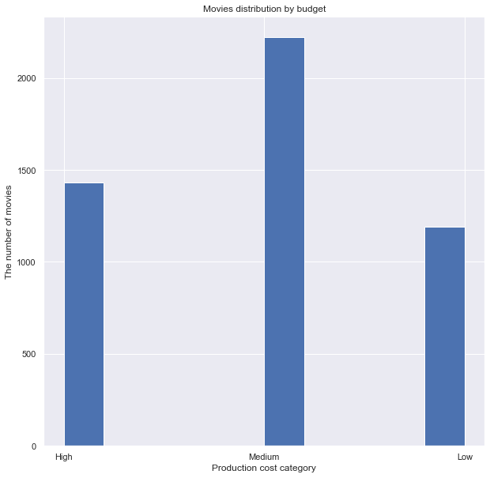

```python
movies_profit['prod_category'].hist()
plt.title('Movies distribution by budget')
plt.xlabel('Production cost category')
plt.ylabel('The number of movies');
```

As we can see, the majority of movies been produced in medium range, followed by high costs, and then low. Let's have a look how profitability been changing over time.

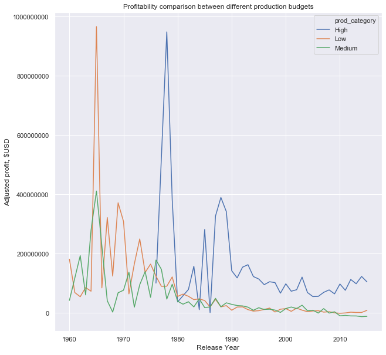

```python
prod_time_agg = movies_profit.groupby(['prod_category','release_year'], as_index = False).median()

plt.ticklabel_format(style='plain', axis='y');
ax = sns.lineplot(x='release_year', y = 'profit_adj', hue = 'prod_category', data = prod_time_agg, markers = True)
plt.ylabel('Adjusted profit, $USD')
plt.xlabel('Release Year')
plt.title('Profitability comparison between different production budgets');
```

As we can see from here, all production budgets were declining in adjusted profit from 1990ies onwards, which may likely to be due to piracy issues.

## Conclusions

###### **NOTE: the conclusion wasn't evaluated on subject of statistical significance, and therefore is tentative.

As a target for analysis, we wanted to understand the cost of movie production, and evaluate what genre could be the most fail-proof within the range of the given dataset.

After cleaning the data and finishing with slightly below 5,000 observations we can draft below conclusions: